# Unveiling Insights: Used Car Analysis Dataset

# **1. Introduction**

In recent years, the automotive industry has witnessed a significant surge in the demand for used cars. People are increasingly turning to the used car market, seeking affordability, variety, and value for money. With this rising trend, the need for insightful data analysis becomes paramount. In this article, we delve into the realm of used car analysis, exploring various aspects of this dynamic market.

hroughout this analysis, we will highlight concrete points that provide valuable takeaways for various stakeholders. From potential used car buyers seeking the best deals to dealers aiming to optimize their inventory, our analysis will cater to a diverse audience.

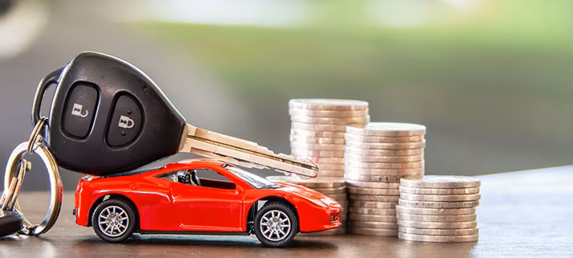

# **2. Problem Statement**

# Developing an Optimal Used Car Price Prediction System for Cars Absolute

## Introduction

Current websites offer price predictions for used cars; however, their accuracy may be suboptimal. As an American company dealing in second-hand cars, Cars Absolute is facing a decline in sales. To address this challenge, the company has assembled a team of data scientists with the following key objectives:

## Key Objectives

1. Develop an Effective Used Car Price Prediction System: The team aims to create a robust and accurate prediction model that considers various features to estimate the selling price of used cars.
2. Boost Customer Confidence: By providing trustworthy and precise valuations, Cars Absolute seeks to instill confidence in potential customers, encouraging them to make informed buying decisions.
3. Revitalize Sales with Transparency: By offering competitive and transparent prices, Cars Absolute aims to rejuvenate its sales and regain its position in the competitive market.

# Data Exploration

- Analyze factors influencing used car prices.
- Identify popular used car models.
- Understand regional variations in demand.
- Evaluate the impact of technological advancements.

# Data Analysis Approach

- Utilize advanced predictive modeling techniques.
- Harness big data for accurate insights.
- Consider a variety of features for prediction.

# Expected Outcomes

- Provide customers with a trustworthy car valuation.
- Enable informed buying and selling decisions.
- Empower Cars Absolute to thrive in the competitive market.

# Conclusion:

- Addressing the challenge of used car price prediction is vital.
- Data-driven insights will transform the used car industry.
- Cars Absolute aims to regain market position with accurate predictions.

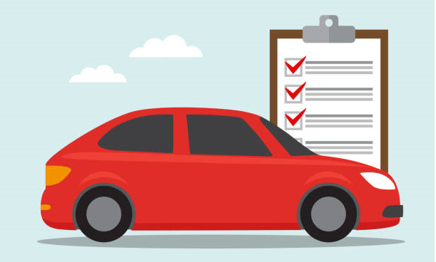

# **3. Installing & Importing Libraries**

- This section is emphasised on installing and importing the necessary libraries that will be required.

### **Installing Libraries**

```python
!pip install -q datascience
!pip install -q pandas-profiling
```

### **Upgrading Libraries**

- **After upgrading** the libraries, you need to **restart the runtime** to make the libraries in sync.
- Make sure not to execute the cell under Installing Libraries and Upgrading Libraries again after restarting the runtime.

```python
!pip install -q --upgrade pandas-profiling
```

### **Importing Libraries**

- You can headstart with the basic libraries as imported inside the cell below.
- If you want to import some additional libraries, feel free to do so.

```python
import pandas as pd
import pandas_profiling as pp

import numpy as np
import matplotlib.pyplot as plt
import seaborn as sns
%matplotlib inline
import warnings
warnings.filterwarnings('ignore')
%reload_ext autoreload
%autoreload 2
```

# **4. Data Acquisition & Description**

- The data for this used car price prediction project was acquired from various online sources and databases that collect information on second-hand car listings. .
- The dataset contains details of used cars, including various attributes that can influence their prices. Web scraping techniques and APIs might have been used to collect the data from multiple platforms.

| Id | Feature | Description |
| --- | --- | --- |
| 01 | car | Car brand name |
| 02 | model | Available car different Variants |
| 03 | year | purchasing Year |
| 04 | body | Body type-Hatchback, Sedan, Crossover etc |
| 05 | mileage | car Mileage |
| 06 | engV | Engine version |
| 07 | engType | Car Fuel type - Petrol, Diesel, gas etc |
| 08 | drive | Wheel Drive Front, back |
| 09 | registration | Check if the vechile is registered |
| 10 | price | Price of Car in $ |

```python
data = pd.read_csv(filepath_or_buffer = 'car_sales.csv')
print('Data Shape:', data.shape)
data.head()
```

```
Data Shape: (9576, 10)
```

|  | car | price | body | mileage | engV | engType | registration | year | model | drive |
| --- | --- | --- | --- | --- | --- | --- | --- | --- | --- | --- |
| 0 | Ford | 15500.0 | crossover | 68 | 2.5 | Gas | yes | 2010 | Kuga | full |
| 1 | Mercedes-Benz | 20500.0 | sedan | 173 | 1.8 | Gas | yes | 2011 | E-Class | rear |
| 2 | Mercedes-Benz | 35000.0 | other | 135 | 5.5 | Petrol | yes | 2008 | CL 550 | rear |
| 3 | Mercedes-Benz | 17800.0 | van | 162 | 1.8 | Diesel | yes | 2012 | B 180 | front |
| 4 | Mercedes-Benz | 33000.0 | vagon | 91 | NaN | Other | yes | 2013 | E-Class | NaN |

#### Data saved in Local machine for faster sync

```python
#data.to_csv("D:\\PERSONAL DATA\DATA SCIENCE\\INSAID\DATA SCIENCE PROJECTS\\Term 3 Project\\ANALYSIS_ON _USED_CARS\\car_sales.csv", index=False)
```

### **Data Description**

- To get some quick description out of the data you can use describe method defined in pandas library.

```python
data.describe()
```

|  | price | mileage | engV | year |
| --- | --- | --- | --- | --- |
| count | 9576.000000 | 9576.000000 | 9142.000000 | 9576.000000 |
| mean | 15633.317316 | 138.862364 | 2.646344 | 2006.605994 |
| std | 24106.523436 | 98.629754 | 5.927699 | 7.067924 |
| min | 0.000000 | 0.000000 | 0.100000 | 1953.000000 |
| 25% | 4999.000000 | 70.000000 | 1.600000 | 2004.000000 |
| 50% | 9200.000000 | 128.000000 | 2.000000 | 2008.000000 |
| 75% | 16700.000000 | 194.000000 | 2.500000 | 2012.000000 |
| max | 547800.000000 | 999.000000 | 99.990000 | 2016.000000 |

```python
# from describe we can see price mileage engV year are numeric columns and we cans these are continuous veriable
```

### **Data Information**

```python
data.head()
```

|  | car | price | body | mileage | engV | engType | registration | year | model | drive |
| --- | --- | --- | --- | --- | --- | --- | --- | --- | --- | --- |
| 0 | Ford | 15500.0 | crossover | 68 | 2.5 | Gas | yes | 2010 | Kuga | full |
| 1 | Mercedes-Benz | 20500.0 | sedan | 173 | 1.8 | Gas | yes | 2011 | E-Class | rear |
| 2 | Mercedes-Benz | 35000.0 | other | 135 | 5.5 | Petrol | yes | 2008 | CL 550 | rear |
| 3 | Mercedes-Benz | 17800.0 | van | 162 | 1.8 | Diesel | yes | 2012 | B 180 | front |
| 4 | Mercedes-Benz | 33000.0 | vagon | 91 | NaN | Other | yes | 2013 | E-Class | NaN |

```python
data.info()
```

```
<class 'pandas.core.frame.DataFrame'>
RangeIndex: 9576 entries, 0 to 9575
Data columns (total 10 columns):
 #   Column        Non-Null Count  Dtype
---  ------        --------------  -----
 0   car           9576 non-null   object
 1   price         9576 non-null   float64
 2   body          9576 non-null   object
 3   mileage       9576 non-null   int64
 4   engV          9142 non-null   float64
 5   engType       9576 non-null   object
 6   registration  9576 non-null   object
 7   year          9576 non-null   int64
 8   model         9576 non-null   object
 9   drive         9065 non-null   object
dtypes: float64(2), int64(2), object(6)
memory usage: 748.2+ KB
```

from info we can see some variables has missing values like engV and drive rest all data looks good

# **5. Data Pre-Profiling**

- This section is emphasised on getting a report about the data.
- You need to perform pandas profiling and get some observations out of it...

```python
profile = pp.ProfileReport(data)
profile.to_file('D:\PERSONAL DATA\DATA SCIENCE\INSAID\DATA SCIENCE PROJECTS\Term 3 Project\ANALYSIS_ON _USED_CARS/data+profile_report.html')
```

# **6. Data Pre-Processing**

### Removed duplicate rows, resulting in 113 duplicates being eliminated.

### Updated incorrect 'mileage' values of 0 with the median value.

### Created mileage bins to handle outliers and separately plotted the outliers.

### Removed older data from before 1975 to reduce outlier impact.

### Imputed missing price values by grouping by year and using the mean price for the specific year.

# 6.1 Handling missing data

```python
data.info()
```

```
<class 'pandas.core.frame.DataFrame'>
RangeIndex: 9576 entries, 0 to 9575
Data columns (total 10 columns):
 #   Column        Non-Null Count  Dtype
---  ------        --------------  -----
 0   car           9576 non-null   object
 1   price         9576 non-null   float64
 2   body          9576 non-null   object
 3   mileage       9576 non-null   int64
 4   engV          9142 non-null   float64
 5   engType       9576 non-null   object
 6   registration  9576 non-null   object
 7   year          9576 non-null   int64
 8   model         9576 non-null   object
 9   drive         9065 non-null   object
dtypes: float64(2), int64(2), object(6)
memory usage: 748.2+ KB
```

```python
#engV          9142 non-null   float64
#drive         9065 non-null   object
data['engV'].isnull().value_counts()
```

```
False    9142
True      434
Name: engV, dtype: int64
```

```python
# there are 434 null values in the engv
#lets find out the unique values
data['engV'].unique()

#from this we can use the mode function
```

```
array([ 2.5 ,  1.8 ,  5.5 ,   nan,  2.  ,  1.5 ,  2.2 ,  1.2 ,  4.8 ,
        5.  ,  3.  ,  4.4 ,  1.6 ,  2.98,  2.4 ,  2.8 ,  3.5 ,  2.99,
        1.9 ,  1.7 ,  4.5 ,  3.6 ,  1.4 ,  2.7 ,  4.  ,  3.8 ,  5.7 ,
       99.99,  3.2 ,  3.7 ,  4.7 ,  1.  , 19.  ,  4.6 ,  0.11,  4.2 ,
        0.8 ,  2.3 ,  6.2 ,  1.3 ,  6.  ,  2.6 ,  0.6 ,  1.25,  5.46,
        6.3 ,  5.6 ,  8.3 ,  3.3 ,  1.1 ,  6.1 ,  0.65,  1.78,  2.1 ,
        3.4 ,  7.  ,  1.46,  5.2 , 75.  ,  6.5 ,  1.23, 17.  ,  8.  ,
        2.9 ,  1.34,  0.7 ,  1.39, 90.  ,  5.3 ,  4.67, 20.  , 14.  ,
       11.5 ,  1.45,  9.  , 10.  ,  4.66, 15.  ,  0.9 , 12.  ,  2.57,
        1.91,  1.33,  2.49,  1.12,  1.36,  2.14, 55.  ,  4.39,  6.75,
        1.59, 28.  ,  8.7 ,  3.1 ,  2.15, 30.  ,  4.3 ,  4.25,  7.2 ,
       85.  ,  5.4 , 66.  ,  2.69,  1.24, 18.  , 22.  , 70.  ,  2.44,
        6.4 ,  1.35,  2.17,  2.46,  2.28,  1.79,  0.14,  1.31,  0.1 ,
       74.  ])
```

```python
data['engV'].describe()
```

```
count    9142.000000
mean        2.646344
std         5.927699
min         0.100000
25%         1.600000
50%         2.000000
75%         2.500000
max        99.990000
Name: engV, dtype: float64
```

```python
data['engV'].agg(['min','max','median', 'mean'])
```

```
min        0.100000
max       99.990000
median     2.000000
mean       2.646344
Name: engV, dtype: float64
```

```python
data['engV']=data['engV'].fillna(data['engV'].mode()[0])
```

```python
data.info()
```

```
<class 'pandas.core.frame.DataFrame'>
RangeIndex: 9576 entries, 0 to 9575
Data columns (total 10 columns):
 #   Column        Non-Null Count  Dtype
---  ------        --------------  -----
 0   car           9576 non-null   object
 1   price         9576 non-null   float64
 2   body          9576 non-null   object
 3   mileage       9576 non-null   int64
 4   engV          9576 non-null   float64
 5   engType       9576 non-null   object
 6   registration  9576 non-null   object
 7   year          9576 non-null   int64
 8   model         9576 non-null   object
 9   drive         9065 non-null   object
dtypes: float64(2), int64(2), object(6)
memory usage: 748.2+ KB
```

```python
#engV is filled with mode()
```

```python
#drive         9065 non-null   object
data['drive'].isnull().value_counts()

# here we can see 511 missing values lets find out the value type
```

```
False    9065
True      511
Name: drive, dtype: int64
```

```python
data['drive'].value_counts()
```

```
front    5188
full     2500
rear     1377
Name: drive, dtype: int64
```

```python
data['drive']=data['drive'].fillna(data['drive'].mode()[0])
data.info()

# we have handeled mising null values very well
```

```
<class 'pandas.core.frame.DataFrame'>
RangeIndex: 9576 entries, 0 to 9575
Data columns (total 10 columns):
 #   Column        Non-Null Count  Dtype
---  ------        --------------  -----
 0   car           9576 non-null   object
 1   price         9576 non-null   float64
 2   body          9576 non-null   object
 3   mileage       9576 non-null   int64
 4   engV          9576 non-null   float64
 5   engType       9576 non-null   object
 6   registration  9576 non-null   object
 7   year          9576 non-null   int64
 8   model         9576 non-null   object
 9   drive         9576 non-null   object
dtypes: float64(2), int64(2), object(6)
memory usage: 748.2+ KB
```

# 6.2 Handling redundant data

- refers to the process of identifying and dealing with duplicate or repetitive information in a dataset.
- Redundant data can lead to several issues, including increased storage requirements, decreased data processing efficiency, and potential inaccuracies in data analysis and modeling.
- It is essential to address redundancy to ensure data integrity and improve the overall quality of the dataset.

```python
data.duplicated().value_counts()

# from this we can see 113 are duplicated data lets explore more
```

```
False    9463
True      113
dtype: int64
```

```python
duplicate_rows =data[data.duplicated()]
duplicate_rows
```

|  | car | price | body | mileage | engV | engType | registration | year | model | drive |
| --- | --- | --- | --- | --- | --- | --- | --- | --- | --- | --- |
| 18 | Nissan | 16600.0 | crossover | 83 | 2.0 | Petrol | yes | 2013 | X-Trail | full |
| 42 | Mercedes-Benz | 20400.0 | sedan | 190 | 1.8 | Gas | yes | 2011 | E-Class | rear |
| 70 | Mercedes-Benz | 0.0 | crossover | 0 | 3.0 | Diesel | yes | 2016 | GLE-Class | full |
| 86 | Toyota | 103999.0 | crossover | 0 | 4.5 | Diesel | yes | 2016 | Land Cruiser 200 | full |
| 98 | Mercedes-Benz | 20400.0 | sedan | 190 | 1.8 | Gas | yes | 2011 | E-Class | rear |
| ... | ... | ... | ... | ... | ... | ... | ... | ... | ... | ... |
| 9156 | Volkswagen | 15700.0 | sedan | 110 | 1.8 | Petrol | yes | 2011 | Passat B7 | front |
| 9163 | Mercedes-Benz | 20500.0 | sedan | 222 | 5.5 | Petrol | yes | 2006 | S 500 | rear |
| 9164 | VAZ | 3900.0 | hatch | 121 | 1.4 | Petrol | yes | 2008 | 1119 | front |
| 9169 | Hyundai | 12900.0 | crossover | 49 | 2.7 | Petrol | yes | 2008 | Tucson | full |
| 9477 | BMW | 77777.0 | sedan | 8 | 4.4 | Petrol | yes | 2014 | 750 | full |

113 rows × 10 columns

```python
data_without_duplicate=data.drop_duplicates()
data_without_duplicate.duplicated().value_counts()

# here we have removed all the duplicate values from the dataset
```

```
False    9463
dtype: int64
```

# 6.3 Handling Inconsistent Data

Inconsistent data refers to data that is not uniform or does not follow a standardized format within a dataset. It occurs when data values are entered or recorded in different ways, leading to variations, discrepancies, or contradictions in the data. Inconsistent data can arise due to various reasons, such as human errors during data entry, data integration from multiple sources with varying formats, or changes in data collection methods over time.

**Examples of Inconsistent Data:**

- Different Units: Measurements recorded using different units (e.g., meters, centimeters, feet) for the same attribute.
- Date Formats: Dates represented in various formats (e.g., "MM/DD/YYYY," "YYYY-MM-DD," "DD/MM/YYYY") across the dataset.
- Categorical Values: Categorical variables with multiple representations for the same category (e.g., "Male," "M," "Male Gender").
- Spelling Errors: Spelling variations or typos in data entries (e.g., "Colarado," "Colorado").
- Encoding Issues: Special characters or non-standard encoding that leads to inconsistencies in data representation.
- Data Entry Mistakes: Human errors while entering data, leading to discrepancies in values.
- Missing Values: Missing data represented differently, such as using "NA," "N/A," or blank cells.

**Strategies to Address Inconsistent Data:**

- **Data Cleaning**: Review and correct errors and inconsistencies during the data cleaning process. This may involve standardizing date formats, converting units, and fixing spelling errors.
- **Data Standardization**: Standardize data representations to a consistent format or encoding. This can be achieved using data transformation techniques.
- **Data Validation Rules**: Implement validation rules during data entry to minimize inconsistencies and enforce standardized formats.
- **Data Integration**: When combining data from multiple sources, ensure that data is transformed and aligned into a consistent structure before integration.
- **Data Quality Checks**: Regularly perform data quality checks to identify and address inconsistencies and errors.
- **Automated Data Entry**: Implement automated data entry systems to reduce human errors.

By addressing inconsistent data, organizations can improve the reliability and accuracy of their data, leading to more robust analysis, reporting, and decision-making processes.

```python
zero_mileagerows = data_without_duplicate[data_without_duplicate['mileage']==0]

zero_mileagerows
# from this analysis we can see the mileage is only has zero rest all the
#columns has correct values so will change the zeros to mean
```

|  | car | price | body | mileage | engV | engType | registration | year | model | drive |
| --- | --- | --- | --- | --- | --- | --- | --- | --- | --- | --- |
| 10 | Nissan | 20447.1540 | crossover | 0 | 1.2 | Petrol | yes | 2016 | Qashqai | front |
| 17 | Mercedes-Benz | 99999.0000 | crossover | 0 | 3.0 | Petrol | yes | 2016 | GLE-Class | full |
| 20 | Land Rover | 0.0000 | crossover | 0 | 4.4 | Diesel | yes | 2016 | Range Rover | full |
| 21 | Nissan | 26033.5530 | crossover | 0 | 1.6 | Diesel | yes | 2016 | X-Trail | full |
| 24 | BMW | 65099.0000 | crossover | 0 | 2.0 | Diesel | yes | 2016 | X5 | full |
| ... | ... | ... | ... | ... | ... | ... | ... | ... | ... | ... |
| 9234 | Hyundai | 12800.7750 | hatch | 0 | 1.4 | Petrol | yes | 2016 | Solaris | front |
| 9268 | Subaru | 37500.0000 | crossover | 0 | 2.0 | Diesel | yes | 2016 | Forester | full |
| 9382 | Suzuki | 15486.9000 | hatch | 0 | 1.2 | Petrol | yes | 2016 | Swift | front |
| 9483 | Opel | 20120.0000 | sedan | 0 | 1.6 | Diesel | yes | 2016 | Astra J | front |
| 9484 | Nissan | 29077.9515 | crossover | 0 | 1.6 | Diesel | yes | 2016 | X-Trail | front |

310 rows × 10 columns

```python
data_without_duplicate['mileage'].agg(['min','max', 'mean', 'median'])
```

```
min         0.000000
max       999.000000
mean      139.924654
median    129.000000
Name: mileage, dtype: float64
```

```python
median_mileage=data_without_duplicate[data_without_duplicate['mileage']!=0]['mileage'].median()
```

```python
data_without_duplicate['mileage']= data_without_duplicate['mileage'].replace(0, median_mileage)
```

```python
data_without_duplicate['mileage'].describe()
```

```
count    9463.000000
mean      144.216105
std        95.069947
min         1.000000
25%        80.000000
50%       131.000000
75%       195.000000
max       999.000000
Name: mileage, dtype: float64
```

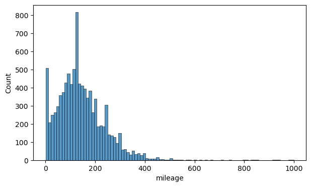

```python
plt.figure(figsize=(7,4))
sns.histplot(data=data_without_duplicate, x ='mileage')
plt.show()
```

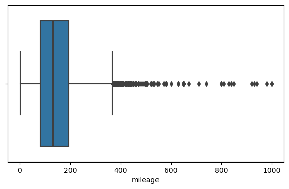

```python
# working on outliers

plt.figure(figsize=(7,4))
sns.boxplot(data=data_without_duplicate, x ='mileage')
plt.show()
```

```python
mileage_outliers=data_without_duplicate[data_without_duplicate['mileage']>400]
```

```python
mileage_outliers.head()

#will handle the outlier by creating bins
```

|  | car | price | body | mileage | engV | engType | registration | year | model | drive |
| --- | --- | --- | --- | --- | --- | --- | --- | --- | --- | --- |
| 102 | Mercedes-Benz | 0.0 | van | 450 | 2.2 | Diesel | yes | 2000 | Vito ïàññ. | front |
| 334 | Toyota | 36000.0 | crossover | 940 | 2.0 | Other | yes | 2009 | Land Cruiser 200 | front |
| 397 | Mazda | 2700.0 | other | 450 | 2.0 | Gas | yes | 1989 | 626 | front |
| 589 | Volkswagen | 8700.0 | other | 520 | 2.5 | Diesel | yes | 1999 | T4 (Transporter) ïàññ. | front |
| 666 | BMW | 30500.0 | sedan | 630 | 2.0 | Petrol | yes | 2010 | 523 | rear |

```python
bin_edges = [0,100,200,300,400,500,600,float('inf')]
bin_lebals = ['0-100','100-200','200-300','300-400','400-500','500-600','600-above']
```

```python
data_without_duplicate['mileage_bins']= pd.cut(data_without_duplicate['mileage'], bins=bin_edges, labels=bin_lebals)
data_without_duplicate.head()
```

|  | car | price | body | mileage | engV | engType | registration | year | model | drive | mileage_bins |
| --- | --- | --- | --- | --- | --- | --- | --- | --- | --- | --- | --- |
| 0 | Ford | 15500.0 | crossover | 68 | 2.5 | Gas | yes | 2010 | Kuga | full | 0-100 |
| 1 | Mercedes-Benz | 20500.0 | sedan | 173 | 1.8 | Gas | yes | 2011 | E-Class | rear | 100-200 |
| 2 | Mercedes-Benz | 35000.0 | other | 135 | 5.5 | Petrol | yes | 2008 | CL 550 | rear | 100-200 |
| 3 | Mercedes-Benz | 17800.0 | van | 162 | 1.8 | Diesel | yes | 2012 | B 180 | front | 100-200 |
| 4 | Mercedes-Benz | 33000.0 | vagon | 91 | 2.0 | Other | yes | 2013 | E-Class | front | 0-100 |

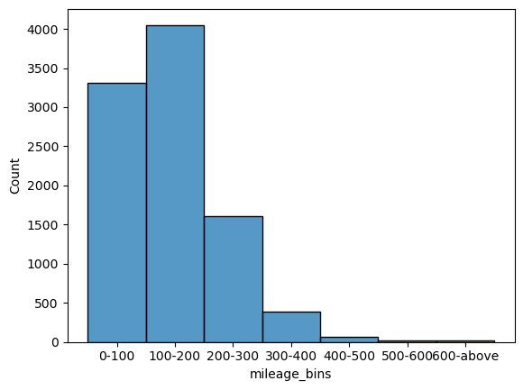

```python
sns.histplot(data=data_without_duplicate, x='mileage_bins')
```

```python
data_without_duplicate['price'].value_counts()
```

```
0.00        240
8500.00      92
6500.00      86
7500.00      85
3500.00      82
           ...
9888.00       1
8050.00       1
36300.00      1
3667.95       1
14474.00      1
Name: price, Length: 1353, dtype: int64
```

```python
data_without_duplicate['price'].describe()
```

```
count      9463.000000
mean      15303.858896
std       23057.384098
min           0.000000
25%        4999.000000
50%        9200.000000
75%       16500.000000
max      547800.000000
Name: price, dtype: float64
```

```python
data_without_duplicate.head()
```

|  | car | price | body | mileage | engV | engType | registration | year | model | drive | mileage_bins |
| --- | --- | --- | --- | --- | --- | --- | --- | --- | --- | --- | --- |
| 0 | Ford | 15500.0 | crossover | 68 | 2.5 | Gas | yes | 2010 | Kuga | full | 0-100 |
| 1 | Mercedes-Benz | 20500.0 | sedan | 173 | 1.8 | Gas | yes | 2011 | E-Class | rear | 100-200 |
| 2 | Mercedes-Benz | 35000.0 | other | 135 | 5.5 | Petrol | yes | 2008 | CL 550 | rear | 100-200 |
| 3 | Mercedes-Benz | 17800.0 | van | 162 | 1.8 | Diesel | yes | 2012 | B 180 | front | 100-200 |
| 4 | Mercedes-Benz | 33000.0 | vagon | 91 | 2.0 | Other | yes | 2013 | E-Class | front | 0-100 |

```python
year_count=data_without_duplicate['year'].groupby(data_without_duplicate['year']).count()

year_count

# ill remove the data older than 1975 as there is lot of single values
```

```
year
1953       1
1958       1
1959       1
1961       2
1962       2
1963       2
1964       1
1968       1
1969       3
1970       1
1971       2
1972       1
1973       1
1974       2
```

[output cut: 43 more lines]

```python
price_zero=data_without_duplicate[data_without_duplicate['price']<=0]
price_zero['year'].value_counts()
```

```
2016    44
2014    22
2015    20
2013    19
2007    19
2012    19
2011    17
2008    16
2001     7
2009     7
2006     6
2000     5
1998     5
1996     5
2003     4
```

[output cut: 20 more lines]

```python
df=data_without_duplicate[data_without_duplicate['year']>=1975]
year_count=df['year'].value_counts()



year_count=pd.DataFrame(year_count)
year_count= year_count.reset_index()
year_count=year_count.rename(columns={'index':'year','year':'count'})
year_count
```

|  | year | count |
| --- | --- | --- |
| 0 | 2008 | 1150 |
| 1 | 2007 | 929 |
| 2 | 2012 | 760 |
| 3 | 2011 | 691 |
| 4 | 2013 | 641 |
| 5 | 2006 | 563 |
| 6 | 2016 | 415 |
| 7 | 2005 | 413 |
| 8 | 2010 | 383 |
| 9 | 2014 | 354 |
| 10 | 2009 | 346 |
| 11 | 2004 | 337 |
| 12 | 2003 | 282 |
| 13 | 2015 | 240 |
| 14 | 2000 | 231 |
| 15 | 2002 | 219 |
| 16 | 2001 | 216 |
| 17 | 1999 | 160 |
| 18 | 1998 | 152 |
| 19 | 1996 | 124 |
| 20 | 1997 | 123 |
| 21 | 1995 | 85 |
| 22 | 1994 | 76 |
| 23 | 1991 | 70 |
| 24 | 1990 | 64 |
| 25 | 1992 | 62 |
| 26 | 1988 | 60 |
| 27 | 1993 | 53 |
| 28 | 1989 | 50 |
| 29 | 1986 | 45 |
| 30 | 1987 | 43 |
| 31 | 1985 | 28 |
| 32 | 1984 | 15 |
| 33 | 1979 | 10 |
| 34 | 1982 | 10 |
| 35 | 1980 | 9 |
| 36 | 1981 | 8 |
| 37 | 1978 | 7 |
| 38 | 1983 | 7 |
| 39 | 1977 | 6 |
| 40 | 1976 | 4 |
| 41 | 1975 | 1 |

```python
df=data_without_duplicate.copy()
df.head()
```

|  | car | price | body | mileage | engV | engType | registration | year | model | drive | mileage_bins |
| --- | --- | --- | --- | --- | --- | --- | --- | --- | --- | --- | --- |
| 0 | Ford | 15500.0 | crossover | 68 | 2.5 | Gas | yes | 2010 | Kuga | full | 0-100 |
| 1 | Mercedes-Benz | 20500.0 | sedan | 173 | 1.8 | Gas | yes | 2011 | E-Class | rear | 100-200 |
| 2 | Mercedes-Benz | 35000.0 | other | 135 | 5.5 | Petrol | yes | 2008 | CL 550 | rear | 100-200 |
| 3 | Mercedes-Benz | 17800.0 | van | 162 | 1.8 | Diesel | yes | 2012 | B 180 | front | 100-200 |
| 4 | Mercedes-Benz | 33000.0 | vagon | 91 | 2.0 | Other | yes | 2013 | E-Class | front | 0-100 |

# Here im getting the mean of each year and will fill the price 0 with mean of corrsponding zero price of that year

```python
mean_year = df.groupby('year').mean()
mean_year['price']
year_count=pd.merge(year_count,mean_year, on='year', how='left')
year_count.head()
```

|  | year | count | price | mileage | engV |
| --- | --- | --- | --- | --- | --- |
| 0 | 2008 | 1150 | 12073.942565 | 133.588696 | 2.542661 |
| 1 | 2007 | 929 | 10607.035361 | 149.693219 | 2.547826 |
| 2 | 2012 | 760 | 18492.191941 | 100.864474 | 2.155053 |
| 3 | 2011 | 691 | 19493.668669 | 108.703329 | 2.454009 |
| 4 | 2013 | 641 | 24448.080086 | 73.290172 | 2.129236 |

```python
year_count=year_count.drop(columns=[ 'price', 'mileage', 'engV'],axis=1)
```

```python
year_count.head()
```

[output not shown]

```python
df_zeros=df[df['price']<=0]
df_zeros
```

|  | car | price | body | mileage | engV | engType | registration | year | model | drive | mileage_bins |
| --- | --- | --- | --- | --- | --- | --- | --- | --- | --- | --- | --- |
| 20 | Land Rover | 0.0 | crossover | 131 | 4.4 | Diesel | yes | 2016 | Range Rover | full | 100-200 |
| 53 | Mercedes-Benz | 0.0 | crossover | 131 | 3.0 | Diesel | yes | 2016 | GLE-Class | full | 100-200 |
| 71 | Toyota | 0.0 | crossover | 131 | 4.5 | Diesel | yes | 2016 | Land Cruiser 200 | full | 100-200 |
| 90 | Porsche | 0.0 | sedan | 22 | 4.8 | Petrol | yes | 2014 | Panamera | full | 0-100 |
| 92 | Audi | 0.0 | crossover | 131 | 3.0 | Diesel | yes | 2015 | Q7 | full | 100-200 |
| ... | ... | ... | ... | ... | ... | ... | ... | ... | ... | ... | ... |
| 9019 | Toyota | 0.0 | hatch | 76 | 1.0 | Petrol | yes | 2007 | Aygo | front | 0-100 |
| 9025 | Mercedes-Benz | 0.0 | crossover | 1 | 3.0 | Petrol | yes | 2016 | GLE-Class | full | 0-100 |
| 9036 | Ford | 0.0 | other | 1 | 5.0 | Petrol | yes | 2014 | Mustang | rear | 0-100 |
| 9442 | Renault | 0.0 | vagon | 137 | 1.9 | Diesel | yes | 2008 | Kangoo ïàññ. | front | 100-200 |
| 9470 | Chrysler | 0.0 | vagon | 198 | 2.0 | Petrol | yes | 2001 | PT Cruiser | front | 100-200 |

240 rows × 11 columns

```python
merged_df_price=pd.merge(df_zeros, year_count ,on='year', how='left')
merged_df_price
```

|  | car | price_x | body | mileage_x | engV_x | engType | registration | year | model | drive | mileage_bins | count | price_y | mileage_y | engV_y |
| --- | --- | --- | --- | --- | --- | --- | --- | --- | --- | --- | --- | --- | --- | --- | --- |
| 0 | Land Rover | 0.0 | crossover | 131 | 4.4 | Diesel | yes | 2016 | Range Rover | full | 100-200 | 415.0 | 55931.989587 | 83.055422 | 2.717518 |
| 1 | Mercedes-Benz | 0.0 | crossover | 131 | 3.0 | Diesel | yes | 2016 | GLE-Class | full | 100-200 | 415.0 | 55931.989587 | 83.055422 | 2.717518 |
| 2 | Toyota | 0.0 | crossover | 131 | 4.5 | Diesel | yes | 2016 | Land Cruiser 200 | full | 100-200 | 415.0 | 55931.989587 | 83.055422 | 2.717518 |
| 3 | Porsche | 0.0 | sedan | 22 | 4.8 | Petrol | yes | 2014 | Panamera | full | 0-100 | 354.0 | 31226.067133 | 45.172316 | 2.286667 |
| 4 | Audi | 0.0 | crossover | 131 | 3.0 | Diesel | yes | 2015 | Q7 | full | 100-200 | 240.0 | 37778.686479 | 35.350000 | 2.303125 |
| ... | ... | ... | ... | ... | ... | ... | ... | ... | ... | ... | ... | ... | ... | ... | ... |
| 235 | Toyota | 0.0 | hatch | 76 | 1.0 | Petrol | yes | 2007 | Aygo | front | 0-100 | 929.0 | 10607.035361 | 149.693219 | 2.547826 |
| 236 | Mercedes-Benz | 0.0 | crossover | 1 | 3.0 | Petrol | yes | 2016 | GLE-Class | full | 0-100 | 415.0 | 55931.989587 | 83.055422 | 2.717518 |
| 237 | Ford | 0.0 | other | 1 | 5.0 | Petrol | yes | 2014 | Mustang | rear | 0-100 | 354.0 | 31226.067133 | 45.172316 | 2.286667 |
| 238 | Renault | 0.0 | vagon | 137 | 1.9 | Diesel | yes | 2008 | Kangoo ïàññ. | front | 100-200 | 1150.0 | 12073.942565 | 133.588696 | 2.542661 |
| 239 | Chrysler | 0.0 | vagon | 198 | 2.0 | Petrol | yes | 2001 | PT Cruiser | front | 100-200 | 216.0 | 5735.833333 | 228.120370 | 3.546296 |

240 rows × 15 columns

```python
df.loc[df['price']<=0,'price'] = merged_df_price['price_y']
```

```python
df
```

|  | car | price | body | mileage | engV | engType | registration | year | model | drive | mileage_bins |
| --- | --- | --- | --- | --- | --- | --- | --- | --- | --- | --- | --- |
| 0 | Ford | 15500.0 | crossover | 68 | 2.5 | Gas | yes | 2010 | Kuga | full | 0-100 |
| 1 | Mercedes-Benz | 20500.0 | sedan | 173 | 1.8 | Gas | yes | 2011 | E-Class | rear | 100-200 |
| 2 | Mercedes-Benz | 35000.0 | other | 135 | 5.5 | Petrol | yes | 2008 | CL 550 | rear | 100-200 |
| 3 | Mercedes-Benz | 17800.0 | van | 162 | 1.8 | Diesel | yes | 2012 | B 180 | front | 100-200 |
| 4 | Mercedes-Benz | 33000.0 | vagon | 91 | 2.0 | Other | yes | 2013 | E-Class | front | 0-100 |
| ... | ... | ... | ... | ... | ... | ... | ... | ... | ... | ... | ... |
| 9571 | Hyundai | 14500.0 | crossover | 140 | 2.0 | Gas | yes | 2011 | Tucson | front | 100-200 |
| 9572 | Volkswagen | 2200.0 | vagon | 150 | 1.6 | Petrol | yes | 1986 | Passat B2 | front | 100-200 |
| 9573 | Mercedes-Benz | 18500.0 | crossover | 180 | 3.5 | Petrol | yes | 2008 | ML 350 | full | 100-200 |
| 9574 | Lexus | 16999.0 | sedan | 150 | 3.5 | Gas | yes | 2008 | ES 350 | front | 100-200 |
| 9575 | Audi | 22500.0 | other | 71 | 3.6 | Petrol | yes | 2007 | Q7 | full | 0-100 |

9463 rows × 11 columns

```python
df.loc[df['price']<=0,'price']

# here we have changed the price 0 to Mean of each year car sold
```

```
Series([], Name: price, dtype: float64)
```

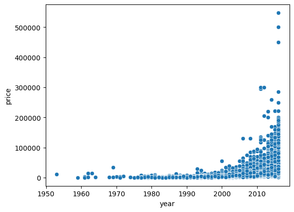

```python
sns.scatterplot(data=df, x='year', y='price')
plt.show()
# because of Price is shwoing zero values the graph is sckiwed will find out the zero values and see
#if we can use mean or median or these are dummy with otehr variables will check out
```

```python
df.head()
```

|  | car | price | body | mileage | engV | engType | registration | year | model | drive | mileage_bins |
| --- | --- | --- | --- | --- | --- | --- | --- | --- | --- | --- | --- |
| 0 | Ford | 15500.0 | crossover | 68 | 2.5 | Gas | yes | 2010 | Kuga | full | 0-100 |
| 1 | Mercedes-Benz | 20500.0 | sedan | 173 | 1.8 | Gas | yes | 2011 | E-Class | rear | 100-200 |
| 2 | Mercedes-Benz | 35000.0 | other | 135 | 5.5 | Petrol | yes | 2008 | CL 550 | rear | 100-200 |
| 3 | Mercedes-Benz | 17800.0 | van | 162 | 1.8 | Diesel | yes | 2012 | B 180 | front | 100-200 |
| 4 | Mercedes-Benz | 33000.0 | vagon | 91 | 2.0 | Other | yes | 2013 | E-Class | front | 0-100 |

```python
df.isnull().sum()
```

```
car               0
price           221
body              0
mileage           0
engV              0
engType           0
registration      0
year              0
model             0
drive             0
mileage_bins      0
dtype: int64
```

```python
#still we can see some price is showins as null will find out the reason and update accordingly
price_null=df.groupby(df['price'].isnull())
price_null_group = price_null.get_group(True)
#price_null_group
```

```python
year_count
```

|  | year | count | price | mileage | engV |
| --- | --- | --- | --- | --- | --- |
| 0 | 2008 | 1150 | 12073.942565 | 133.588696 | 2.542661 |
| 1 | 2007 | 929 | 10607.035361 | 149.693219 | 2.547826 |
| 2 | 2012 | 760 | 18492.191941 | 100.864474 | 2.155053 |
| 3 | 2011 | 691 | 19493.668669 | 108.703329 | 2.454009 |
| 4 | 2013 | 641 | 24448.080086 | 73.290172 | 2.129236 |
| 5 | 2006 | 563 | 9811.650888 | 161.424512 | 2.549023 |
| 6 | 2016 | 415 | 55931.989587 | 83.055422 | 2.717518 |
| 7 | 2005 | 413 | 8805.392252 | 183.220339 | 2.742615 |
| 8 | 2010 | 383 | 18061.567232 | 116.798956 | 2.604935 |
| 9 | 2014 | 354 | 31226.067133 | 45.172316 | 2.286667 |
| 10 | 2009 | 346 | 15194.502890 | 120.199422 | 2.662428 |
| 11 | 2004 | 337 | 7939.790356 | 193.050445 | 2.951573 |
| 12 | 2003 | 282 | 7387.110152 | 209.936170 | 2.639645 |
| 13 | 2015 | 240 | 37778.686479 | 35.350000 | 2.303125 |
| 14 | 2000 | 231 | 5307.934416 | 241.259740 | 3.577229 |
| 15 | 2002 | 219 | 6416.634703 | 212.534247 | 3.230731 |
| 16 | 2001 | 216 | 5735.833333 | 228.120370 | 3.546296 |
| 17 | 1999 | 160 | 4580.425000 | 240.218750 | 2.809937 |
| 18 | 1998 | 152 | 4498.735197 | 259.046053 | 3.497237 |
| 19 | 1996 | 124 | 3774.647177 | 263.258065 | 3.043468 |
| 20 | 1997 | 123 | 4836.910569 | 263.292683 | 2.712195 |
| 21 | 1995 | 85 | 4227.458824 | 247.082353 | 2.135294 |
| 22 | 1994 | 76 | 3801.602303 | 233.473684 | 2.156447 |
| 23 | 1991 | 70 | 2739.885714 | 244.042857 | 1.901429 |
| 24 | 1990 | 64 | 2399.308594 | 164.703125 | 1.806250 |
| 25 | 1992 | 62 | 2931.822581 | 199.822581 | 3.465968 |
| 26 | 1988 | 60 | 2166.750000 | 190.083333 | 1.993333 |
| 27 | 1993 | 53 | 3900.495283 | 231.905660 | 2.473585 |
| 28 | 1989 | 50 | 2288.930000 | 188.920000 | 3.757800 |
| 29 | 1986 | 45 | 1571.848333 | 164.733333 | 3.848667 |
| 30 | 1987 | 43 | 2194.554651 | 206.395349 | 4.105581 |
| 31 | 1985 | 28 | 2171.339286 | 163.714286 | 2.107143 |
| 32 | 1984 | 15 | 1471.215000 | 190.200000 | 1.546667 |
| 33 | 1979 | 10 | 2610.112500 | 55.500000 | 1.780000 |
| 34 | 1982 | 10 | 1599.675000 | 122.000000 | 2.539000 |
| 35 | 1980 | 9 | 1933.750000 | 115.111111 | 1.688889 |
| 36 | 1981 | 8 | 2762.500000 | 96.500000 | 2.175000 |
| 37 | 1978 | 7 | 2728.571429 | 171.714286 | 2.042857 |
| 38 | 1983 | 7 | 1629.417857 | 86.428571 | 1.971429 |
| 39 | 1977 | 6 | 2217.764167 | 62.166667 | 1.650000 |
| 40 | 1976 | 4 | 1070.000000 | 119.250000 | 2.000000 |
| 41 | 1975 | 1 | 750.000000 | 20.000000 | 1.500000 |

```python
#here we have added the ,mean price in the nan column

year_price_mapping=year_count.set_index('year')['price']
price_null_group['mean_price']=price_null_group['year'].map(year_price_mapping)
price_null_group.head()
```

|  | car | price | body | mileage | engV | engType | registration | year | model | drive | mileage_bins | mean_price |
| --- | --- | --- | --- | --- | --- | --- | --- | --- | --- | --- | --- | --- |
| 241 | Mercedes-Benz | NaN | vagon | 200 | 2.2 | Diesel | yes | 2006 | Vito ïàññ. | rear | 100-200 | 9811.650888 |
| 244 | Audi | NaN | crossover | 65 | 3.0 | Diesel | yes | 2013 | A6 | full | 0-100 | 24448.080086 |
| 249 | Porsche | NaN | crossover | 200 | 4.8 | Petrol | yes | 2007 | Cayenne | full | 100-200 | 10607.035361 |
| 265 | Porsche | NaN | sedan | 14 | 3.6 | Petrol | yes | 2014 | Panamera | full | 0-100 | 31226.067133 |
| 277 | BMW | NaN | crossover | 8 | 2.0 | Diesel | yes | 2016 | X5 | full | 0-100 | 55931.989587 |

```python
grouped_df=price_null_group[['year','price','mean_price']]
```

```python
price_null_group['price'].fillna(price_null_group['mean_price'],inplace=True)
```

```python
price_null_group
```

|  | car | price | body | mileage | engV | engType | registration | year | model | drive | mileage_bins | mean_price |
| --- | --- | --- | --- | --- | --- | --- | --- | --- | --- | --- | --- | --- |
| 241 | Mercedes-Benz | 9811.650888 | vagon | 200 | 2.2 | Diesel | yes | 2006 | Vito ïàññ. | rear | 100-200 | 9811.650888 |
| 244 | Audi | 24448.080086 | crossover | 65 | 3.0 | Diesel | yes | 2013 | A6 | full | 0-100 | 24448.080086 |
| 249 | Porsche | 10607.035361 | crossover | 200 | 4.8 | Petrol | yes | 2007 | Cayenne | full | 100-200 | 10607.035361 |
| 265 | Porsche | 31226.067133 | sedan | 14 | 3.6 | Petrol | yes | 2014 | Panamera | full | 0-100 | 31226.067133 |
| 277 | BMW | 55931.989587 | crossover | 8 | 2.0 | Diesel | yes | 2016 | X5 | full | 0-100 | 55931.989587 |
| ... | ... | ... | ... | ... | ... | ... | ... | ... | ... | ... | ... | ... |
| 9019 | Toyota | 10607.035361 | hatch | 76 | 1.0 | Petrol | yes | 2007 | Aygo | front | 0-100 | 10607.035361 |
| 9025 | Mercedes-Benz | 55931.989587 | crossover | 1 | 3.0 | Petrol | yes | 2016 | GLE-Class | full | 0-100 | 55931.989587 |
| 9036 | Ford | 31226.067133 | other | 1 | 5.0 | Petrol | yes | 2014 | Mustang | rear | 0-100 | 31226.067133 |
| 9442 | Renault | 12073.942565 | vagon | 137 | 1.9 | Diesel | yes | 2008 | Kangoo ïàññ. | front | 100-200 | 12073.942565 |
| 9470 | Chrysler | 5735.833333 | vagon | 198 | 2.0 | Petrol | yes | 2001 | PT Cruiser | front | 100-200 | 5735.833333 |

221 rows × 12 columns

```python
df2=df.copy()
```

```python
df['price']=df['price'].combine_first(price_null_group['price'])
```

```python
df=df[df['year']>=1975]
df.isnull().sum()
```

```
car             0
price           0
body            0
mileage         0
engV            0
engType         0
registration    0
year            0
model           0
drive           0
mileage_bins    0
dtype: int64
```

```python
na_row=df[df.isna().any(axis=1)]
na_row
```

|  | car | price | body | mileage | engV | engType | registration | year | model | drive | mileage_bins |
| --- | --- | --- | --- | --- | --- | --- | --- | --- | --- | --- | --- |

# **7. Data Post-Profiling**

- This section is emphasised on getting a report about the data after the data manipulation.
- You may end up observing some new changes, so keep it under check and make right observations.

```python
df.info()
```

```
<class 'pandas.core.frame.DataFrame'>
Int64Index: 9442 entries, 0 to 9575
Data columns (total 11 columns):
 #   Column        Non-Null Count  Dtype
---  ------        --------------  -----
 0   car           9442 non-null   object
 1   price         9442 non-null   float64
 2   body          9442 non-null   object
 3   mileage       9442 non-null   int64
 4   engV          9442 non-null   float64
 5   engType       9442 non-null   object
 6   registration  9442 non-null   object
 7   year          9442 non-null   int64
 8   model         9442 non-null   object
 9   drive         9442 non-null   object
 10  mileage_bins  9442 non-null   category
dtypes: category(1), float64(2), int64(2), object(6)
memory usage: 821.0+ KB
```

# **8. Exploratory Data Analysis**

- This section is emphasised on asking the right questions and perform analysis using the data.
- Note that there is no limit how deep you can go, but make sure not to get distracted from right track.

# 8.1 What is the distribution of car prices in the dataset?

### Top 5 car prices and their corresponding counts:

$8500.0: 92

$6500.0: 86

$7500.0: 85

$3500.0: 82

$10500.0: 81

```python
price_outliers=df[df['price'] <100000]
price_outliers
```

|  | car | price | body | mileage | engV | engType | registration | year | model | drive | mileage_bins |
| --- | --- | --- | --- | --- | --- | --- | --- | --- | --- | --- | --- |
| 0 | Ford | 15500.0 | crossover | 68 | 2.5 | Gas | yes | 2010 | Kuga | full | 0-100 |
| 1 | Mercedes-Benz | 20500.0 | sedan | 173 | 1.8 | Gas | yes | 2011 | E-Class | rear | 100-200 |
| 2 | Mercedes-Benz | 35000.0 | other | 135 | 5.5 | Petrol | yes | 2008 | CL 550 | rear | 100-200 |
| 3 | Mercedes-Benz | 17800.0 | van | 162 | 1.8 | Diesel | yes | 2012 | B 180 | front | 100-200 |
| 4 | Mercedes-Benz | 33000.0 | vagon | 91 | 2.0 | Other | yes | 2013 | E-Class | front | 0-100 |
| ... | ... | ... | ... | ... | ... | ... | ... | ... | ... | ... | ... |
| 9571 | Hyundai | 14500.0 | crossover | 140 | 2.0 | Gas | yes | 2011 | Tucson | front | 100-200 |
| 9572 | Volkswagen | 2200.0 | vagon | 150 | 1.6 | Petrol | yes | 1986 | Passat B2 | front | 100-200 |
| 9573 | Mercedes-Benz | 18500.0 | crossover | 180 | 3.5 | Petrol | yes | 2008 | ML 350 | full | 100-200 |
| 9574 | Lexus | 16999.0 | sedan | 150 | 3.5 | Gas | yes | 2008 | ES 350 | front | 100-200 |
| 9575 | Audi | 22500.0 | other | 71 | 3.6 | Petrol | yes | 2007 | Q7 | full | 0-100 |

9315 rows × 11 columns

```python
price_outliers['price'].agg(['min', 'max', 'mean', 'median'])
```

```
min         280.000000
max       99999.000000
mean      14053.535653
median     9500.000000
Name: price, dtype: float64
```

```python
price_outliers['price'].value_counts().sort_values(ascending=False).head()
```

```
8500.0     92
6500.0     86
7500.0     85
3500.0     82
10500.0    81
Name: price, dtype: int64
```

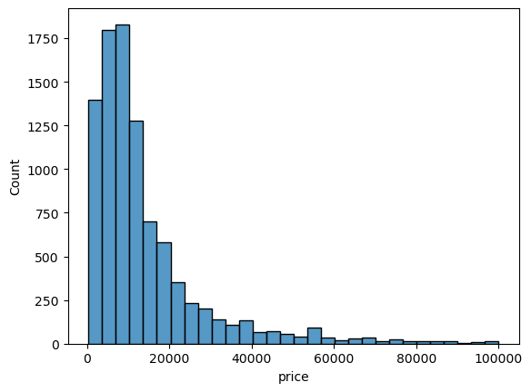

```python
sns.histplot(data=price_outliers, x='price',bins=30 )
```

**Price Count**

8500.0 92 6500.0 86 7500.0 85 3500.0 82 10500.0 81

from the count we found above are the top destribution of price to car counts

# 8.2 How does the price of used cars vary with respect to their make and model?

### Answer :

**Price varies based on the year of manufacture, with more recent cars having higher values.**

**Bentley has the highest resale price, and most used cars for sale are from 2000 onwards.**

**Most used cars are priced below 2 million.**

```python
df.head()
```

|  | car | price | body | mileage | engV | engType | registration | year | model | drive | mileage_bins |
| --- | --- | --- | --- | --- | --- | --- | --- | --- | --- | --- | --- |
| 0 | Ford | 15500.0 | crossover | 68 | 2.5 | Gas | yes | 2010 | Kuga | full | 0-100 |
| 1 | Mercedes-Benz | 20500.0 | sedan | 173 | 1.8 | Gas | yes | 2011 | E-Class | rear | 100-200 |
| 2 | Mercedes-Benz | 35000.0 | other | 135 | 5.5 | Petrol | yes | 2008 | CL 550 | rear | 100-200 |
| 3 | Mercedes-Benz | 17800.0 | van | 162 | 1.8 | Diesel | yes | 2012 | B 180 | front | 100-200 |
| 4 | Mercedes-Benz | 33000.0 | vagon | 91 | 2.0 | Other | yes | 2013 | E-Class | front | 0-100 |

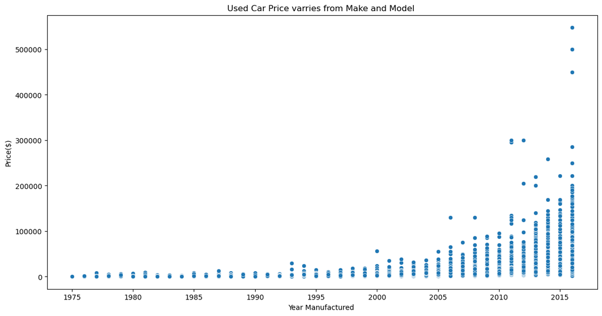

```python
paper=plt.figure(figsize=(14,7))
sns.scatterplot(data=df,x='year', y='price')
plt.xlabel("Year Manufactured ")
plt.xticks(np.arange(1975, 2020,5))
plt.ylabel("Price($)")
plt.title("Used Car Price varries from Make and Model ")
plt.show()
```

### from the table we can understand the the price varies on year of manufactured the more recent has more values

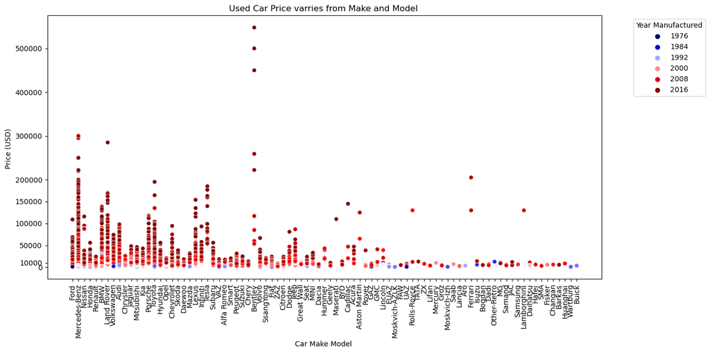

```python
paper=plt.figure(figsize=(14,7))
bins=[0,10000,50000,100000,150000,200000,300000,400000,500000]
sns.scatterplot(data=df,x=df['car'].sort_values( ascending=True), y='price', hue='year', palette='seismic')
plt.xlabel("Car Make Model ")
plt.xticks(rotation=90)
plt.yticks(bins)
plt.ylabel("Price (USD) ")
plt.legend(title='Year Manufactured', bbox_to_anchor=(1.05, 1), loc='upper left')
plt.title("Used Car Price varries from Make and Model ")
plt.tight_layout()
plt.show()
```

### we can say most of the used cars from 2000 later

### most of the used cars are saling below 2 million

# 8.3 What are the most common car body types available in the dataset?

### Answer:-

**Sedan is the most common body type with 3600 cars for sale, followed by crossover with around 2000 cars.**

```python
df.head()
```

|  | car | price | body | mileage | engV | engType | registration | year | model | drive | mileage_bins |
| --- | --- | --- | --- | --- | --- | --- | --- | --- | --- | --- | --- |
| 0 | Ford | 15500.0 | crossover | 68 | 2.5 | Gas | yes | 2010 | Kuga | full | 0-100 |
| 1 | Mercedes-Benz | 20500.0 | sedan | 173 | 1.8 | Gas | yes | 2011 | E-Class | rear | 100-200 |
| 2 | Mercedes-Benz | 35000.0 | other | 135 | 5.5 | Petrol | yes | 2008 | CL 550 | rear | 100-200 |
| 3 | Mercedes-Benz | 17800.0 | van | 162 | 1.8 | Diesel | yes | 2012 | B 180 | front | 100-200 |
| 4 | Mercedes-Benz | 33000.0 | vagon | 91 | 2.0 | Other | yes | 2013 | E-Class | front | 0-100 |

```python
carbody_count=df['body'].value_counts().sort_values(ascending=True)
carbody_count
```

```
vagon         719
other         827
van          1038
hatch        1247
crossover    2005
sedan        3606
Name: body, dtype: int64
```

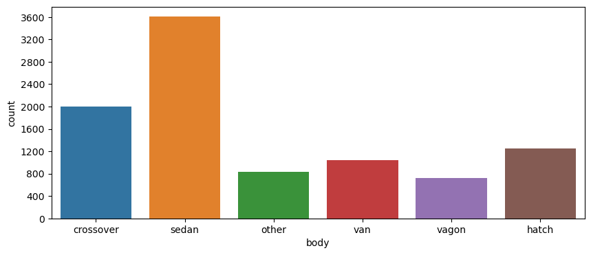

```python
paper = plt.figure(figsize=(10,4))
sns.countplot(data=df, x=df['body'])
plt.yticks(np.arange(0,4000,400))
plt.show()
```

### as we can see the sedan body type is 3600 on saling then cross over also has around 2000 cars on saling

### vagon has very less cars on for sale

# 8.4 Are there any specific brands that tend to have higher resale value than others?

### Answer:-

**Bentley has the highest resale value.**

**The top 2 brands with high resale values are Mercedes-Benz and Land-Rover.**

```python
df_EDA =df.copy()
```

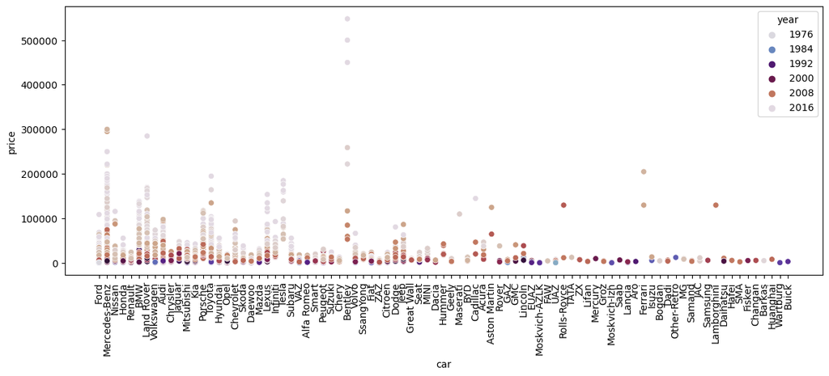

```python
paper =plt.figure(figsize=(14,5))
sns.scatterplot(data=df, x='car',y='price' , hue='year', palette='twilight')
plt.xticks(rotation=90)
plt.show()
```

## from the analysis we can see Bentley has highest resale values

## and for top 2 we can see Mercedez-Benz , Land-Rover

# 8.5 Are there any outliers in the mileage or price data? How do they affect the analysis?

### Answer:-

**Outliers were identified in mileage and price using interquartile range (IQR).**

**Mileage outliers were plotted separately.**

```python
mileage_iqr =df['mileage'].quantile(0.75)-df['mileage'].quantile(0.25)
price_iqr =df['price'].quantile(0.75)-df['price'].quantile(0.25)
```

```python
mileage_lower_bound = df['mileage'].quantile(0.25) - 1.5 * mileage_iqr
mileage_upper_bound = df['mileage'].quantile(0.75) + 1.5 * mileage_iqr
```

```python
price_lower_bound = df['price'].quantile(0.25) - 1.5 * price_iqr
price_upper_bound = df['price'].quantile(0.75) + 1.5 * price_iqr
```

```python
mileage_outliers = df[(df['mileage'] < mileage_lower_bound) | (df['mileage'] > mileage_upper_bound)]
print("Outliers in Mileage:")
print(mileage_outliers)
price_outliers = df[(df['price'] < price_lower_bound) | (df['price'] > price_upper_bound)]


print("Outliers in price:")
print(price_outliers)
```

```
Outliers in Mileage:
                car         price       body  mileage  engV engType  \
102   Mercedes-Benz  55931.989587        van      450   2.2  Diesel
334          Toyota  36000.000000  crossover      940   2.0   Other
354      Volkswagen   4500.000000        van      380   2.0  Diesel
397           Mazda   2700.000000      other      450   2.0     Gas
416            Audi   3600.000000      sedan      374   2.5  Diesel
...             ...           ...        ...      ...   ...     ...
9439            ZAZ   1148.550000      hatch      500   1.2     Gas
9440  Mercedes-Benz  10000.000000        van      450   2.0  Diesel
9512  Mercedes-Benz   5000.000000      sedan      382   2.0  Petrol
9530           Audi   5000.000000      sedan      370   2.3  Petrol
9532  Mercedes-Benz   7900.000000        van      427   2.9  Diesel

     registration  year               model  drive mileage_bins
```

[output cut: 41 more lines]

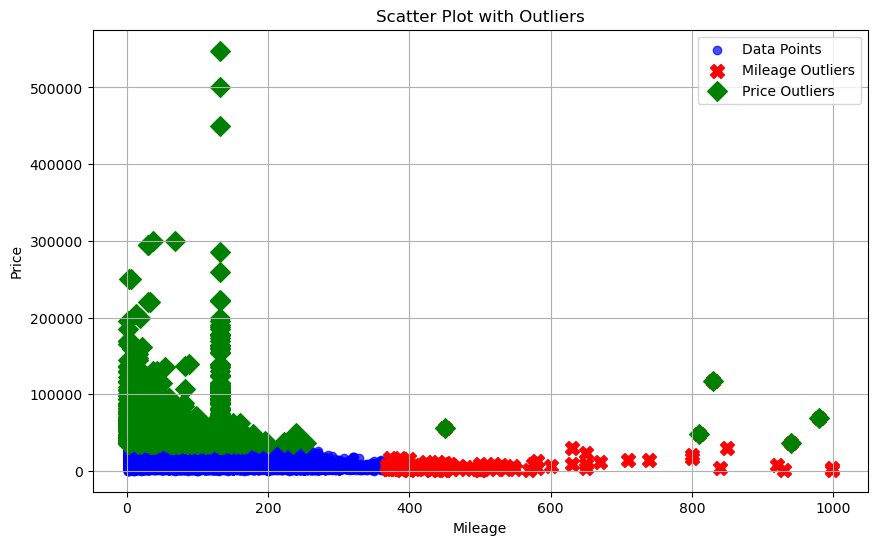

```python
plt.figure(figsize=(10, 6))
plt.scatter(df['mileage'], df['price'], label='Data Points', alpha=0.7, color='blue')
plt.scatter(mileage_outliers['mileage'], mileage_outliers['price'], label='Mileage Outliers', color='red', marker='X', s=100)
plt.scatter(price_outliers['mileage'], price_outliers['price'], label='Price Outliers', color='green', marker='D', s=100)

plt.xlabel("Mileage")
plt.ylabel("Price")
plt.title("Scatter Plot with Outliers")
plt.legend()
plt.grid()
plt.show()
```

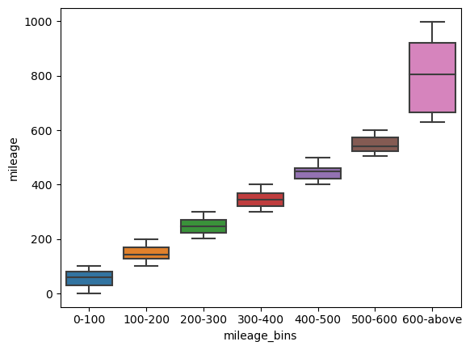

```python
sns.boxplot(data=df,x='mileage_bins', y='mileage')
```

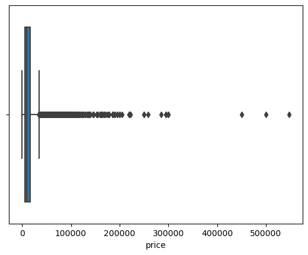

```python
sns.boxplot(data=df,x='price')
```

# 8.6 What is the average age of used cars in the dataset?

### Answer:-

**The average age of used cars in the dataset is approximately 16.38 years.**

```python
df.head()
```

|  | car | price | body | mileage | engV | engType | registration | year | model | drive | mileage_bins |
| --- | --- | --- | --- | --- | --- | --- | --- | --- | --- | --- | --- |
| 0 | Ford | 15500.0 | crossover | 68 | 2.5 | Gas | yes | 2010 | Kuga | full | 0-100 |
| 1 | Mercedes-Benz | 20500.0 | sedan | 173 | 1.8 | Gas | yes | 2011 | E-Class | rear | 100-200 |
| 2 | Mercedes-Benz | 35000.0 | other | 135 | 5.5 | Petrol | yes | 2008 | CL 550 | rear | 100-200 |
| 3 | Mercedes-Benz | 17800.0 | van | 162 | 1.8 | Diesel | yes | 2012 | B 180 | front | 100-200 |
| 4 | Mercedes-Benz | 33000.0 | vagon | 91 | 2.0 | Other | yes | 2013 | E-Class | front | 0-100 |

```python
df['year'].mean()
```

```
2006.615971192544
```

```python
from datetime import datetime
```

```python
current_year=datetime.now().year
df['car_age']=current_year-df['year']
```

```python
avg_car_age=df['car_age'].mean()
print("Avarage Car age in the dataset is =",format(avg_car_age))
```

```
Avarage Car age in the dataset is = 16.384028807456048
```

# 8.7 What is the distribution of purchases across different product categories?

### Answer:-

**Volkswagen and Mercedes-Benz are the most popular brands based on car counts.**

**Top 5 popular brands:** Volkswagen: 927 cars

Mercedes-Benz: 884 cars

BMW: 684 cars

Toyota: 529 cars

VAZ: 484 cars

```python
df.head()
```

|  | car | price | body | mileage | engV | engType | registration | year | model | drive | mileage_bins | car_age |
| --- | --- | --- | --- | --- | --- | --- | --- | --- | --- | --- | --- | --- |
| 0 | Ford | 15500.0 | crossover | 68 | 2.5 | Gas | yes | 2010 | Kuga | full | 0-100 | 13 |
| 1 | Mercedes-Benz | 20500.0 | sedan | 173 | 1.8 | Gas | yes | 2011 | E-Class | rear | 100-200 | 12 |
| 2 | Mercedes-Benz | 35000.0 | other | 135 | 5.5 | Petrol | yes | 2008 | CL 550 | rear | 100-200 | 15 |
| 3 | Mercedes-Benz | 17800.0 | van | 162 | 1.8 | Diesel | yes | 2012 | B 180 | front | 100-200 | 11 |
| 4 | Mercedes-Benz | 33000.0 | vagon | 91 | 2.0 | Other | yes | 2013 | E-Class | front | 0-100 | 10 |

```python
df['car'].value_counts()
```

```
Volkswagen       927
Mercedes-Benz    884
BMW              684
Toyota           529
VAZ              484
                ...
ZX                 1
Other-Retro        1
Mercury            1
Maserati           1
Buick              1
Name: car, Length: 87, dtype: int64
```

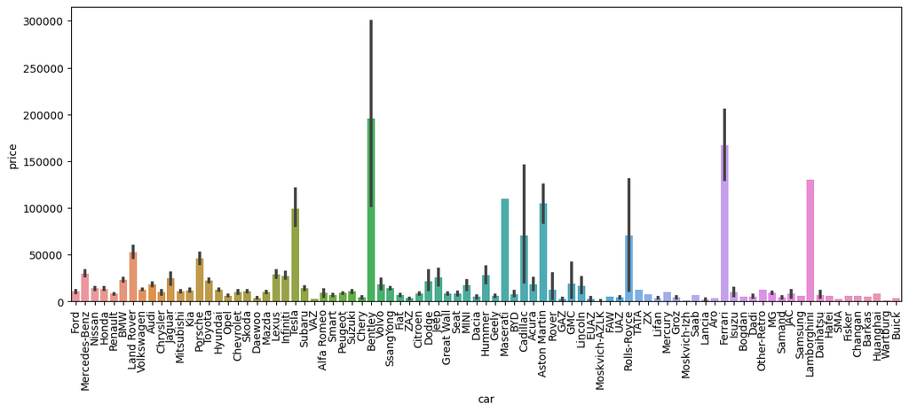

```python
paper=plt.figure(figsize=(14,5))
sns.barplot(data=df, x='car', y='price')
plt.xticks(rotation=90)
plt.show()
```

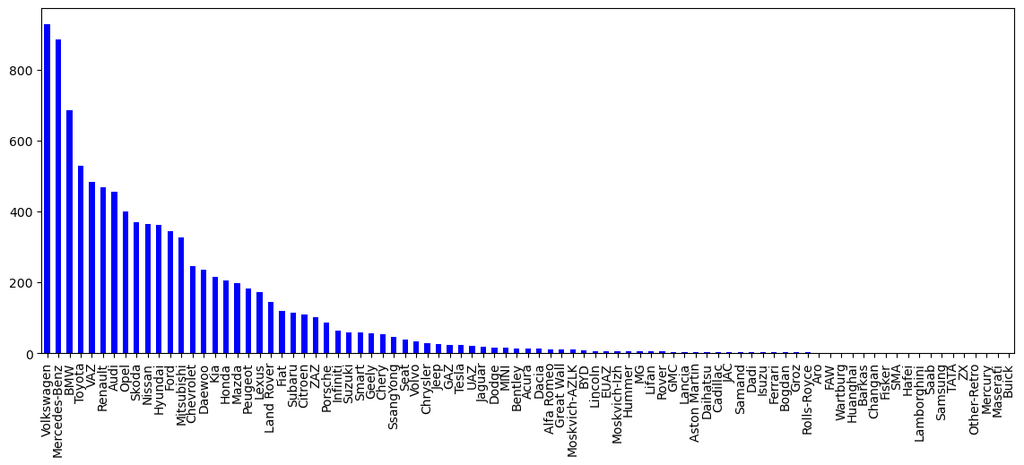

```python
car_cat=df['car'].value_counts()
paper=plt.figure(figsize=(14,5))
car_cat.plot(kind='bar', color='Blue')
```

```python
car_cat.head()
```

```
Volkswagen       927
Mercedes-Benz    884
BMW              684
Toyota           529
VAZ              484
Name: car, dtype: int64
```

## from the observations we can say Volkswagen , Mercedes-Benz have highest saling among the others

## here are top 5

#### Volkswagen 927

#### Mercedes-Benz 884

#### BMW 684

#### Toyota 529

#### VAZ 484

```python
#this is good practice to copy the data
df2=df.copy()
```

#### below i have group by car category with price and counted them

```python
car_cat_purchase_counts = df.groupby(['car', 'price']).size()
car_cat_purchase_counts
```

```
car    price
Acura  8550.000000     1
       8699.000000     2
       8700.000000     1
       11111.000000    1
       12900.000000    1
                      ..
ËUAZ   1300.000000     1
       1500.000000     1
       2739.885714     1
       3500.000000     1
       5950.000000     1
Length: 5406, dtype: int64
```

#### converted the series to dataset and given the columns

```python
car_cat_purchase_counts_df = car_cat_purchase_counts.reset_index(name='count')
car_cat_purchase_counts_df
```

|  | car | price | count |
| --- | --- | --- | --- |
| 0 | Acura | 8550.000000 | 1 |
| 1 | Acura | 8699.000000 | 2 |
| 2 | Acura | 8700.000000 | 1 |
| 3 | Acura | 11111.000000 | 1 |
| 4 | Acura | 12900.000000 | 1 |
| ... | ... | ... | ... |
| 5401 | ËUAZ | 1300.000000 | 1 |
| 5402 | ËUAZ | 1500.000000 | 1 |
| 5403 | ËUAZ | 2739.885714 | 1 |
| 5404 | ËUAZ | 3500.000000 | 1 |
| 5405 | ËUAZ | 5950.000000 | 1 |

5406 rows × 3 columns

# 8.8 How does the mileage of used cars change as their age increases?

### Answer:-

**Mileage generally increases with the age of the car.**

```python
df.head()
```

|  | car | price | body | mileage | engV | engType | registration | year | model | drive | mileage_bins | car_age |
| --- | --- | --- | --- | --- | --- | --- | --- | --- | --- | --- | --- | --- |
| 0 | Ford | 15500.0 | crossover | 68 | 2.5 | Gas | yes | 2010 | Kuga | full | 0-100 | 13 |
| 1 | Mercedes-Benz | 20500.0 | sedan | 173 | 1.8 | Gas | yes | 2011 | E-Class | rear | 100-200 | 12 |
| 2 | Mercedes-Benz | 35000.0 | other | 135 | 5.5 | Petrol | yes | 2008 | CL 550 | rear | 100-200 | 15 |
| 3 | Mercedes-Benz | 17800.0 | van | 162 | 1.8 | Diesel | yes | 2012 | B 180 | front | 100-200 | 11 |
| 4 | Mercedes-Benz | 33000.0 | vagon | 91 | 2.0 | Other | yes | 2013 | E-Class | front | 0-100 | 10 |

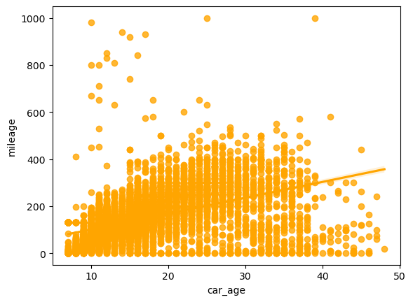

```python
sns.regplot(data=df, x='car_age', y='mileage', color='Orange', marker='o' )
```

# 8.9 Is there a correlation between the age of the car and its price?

### Answer:-

**There is a negative correlation between the age of the car and its price.**

**The younger the car, the higher the price, and vice versa.**

```python
df.head()
```

|  | car | price | body | mileage | engV | engType | registration | year | model | drive | mileage_bins | car_age |
| --- | --- | --- | --- | --- | --- | --- | --- | --- | --- | --- | --- | --- |
| 0 | Ford | 15500.0 | crossover | 68 | 2.5 | Gas | yes | 2010 | Kuga | full | 0-100 | 13 |
| 1 | Mercedes-Benz | 20500.0 | sedan | 173 | 1.8 | Gas | yes | 2011 | E-Class | rear | 100-200 | 12 |
| 2 | Mercedes-Benz | 35000.0 | other | 135 | 5.5 | Petrol | yes | 2008 | CL 550 | rear | 100-200 | 15 |
| 3 | Mercedes-Benz | 17800.0 | van | 162 | 1.8 | Diesel | yes | 2012 | B 180 | front | 100-200 | 11 |
| 4 | Mercedes-Benz | 33000.0 | vagon | 91 | 2.0 | Other | yes | 2013 | E-Class | front | 0-100 | 10 |

```python
df.corr()
```

|  | price | mileage | engV | year | car_age |
| --- | --- | --- | --- | --- | --- |
| price | 1.000000 | -0.262452 | 0.054168 | 0.408425 | -0.408425 |
| mileage | -0.262452 | 1.000000 | 0.055529 | -0.481358 | 0.481358 |
| engV | 0.054168 | 0.055529 | 1.000000 | -0.028214 | 0.028214 |
| year | 0.408425 | -0.481358 | -0.028214 | 1.000000 | -1.000000 |
| car_age | -0.408425 | 0.481358 | 0.028214 | -1.000000 | 1.000000 |

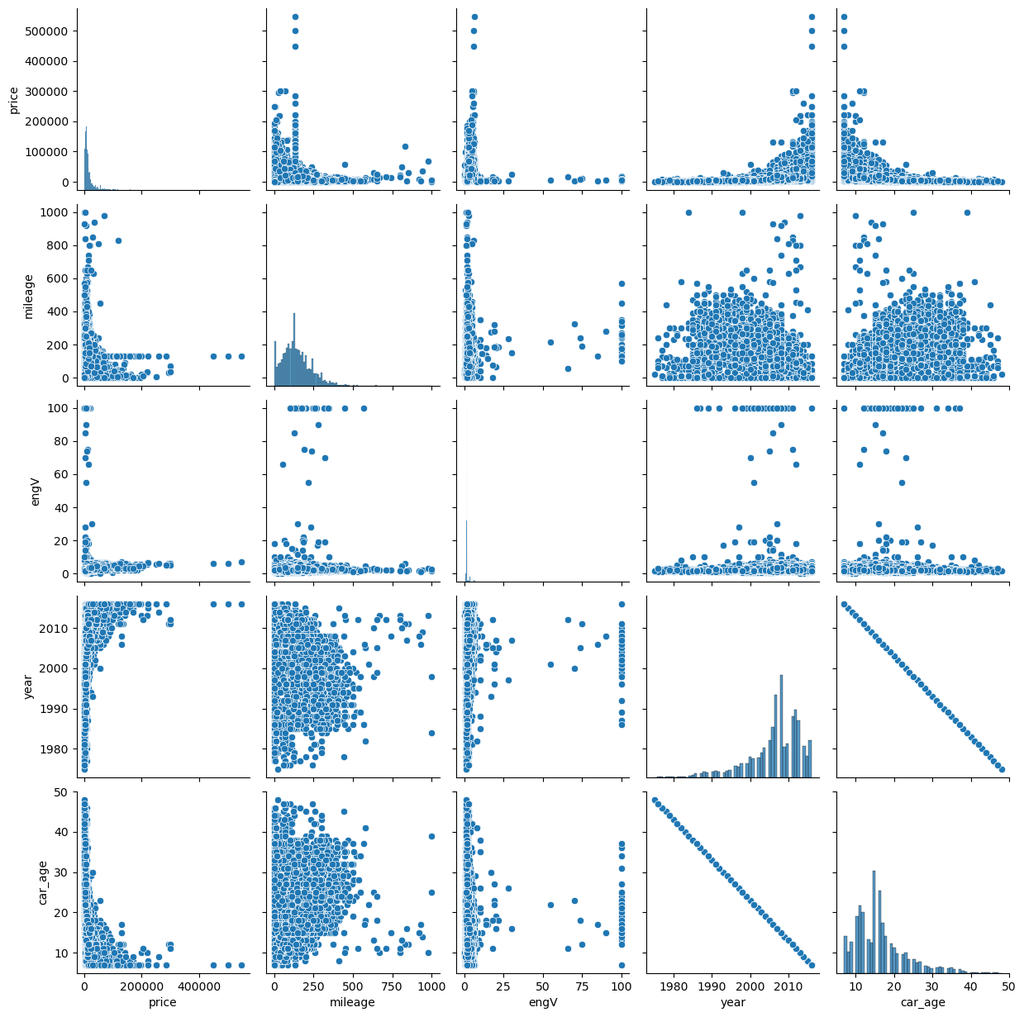

```python
sns.pairplot(data=df, kind='scatter')
```

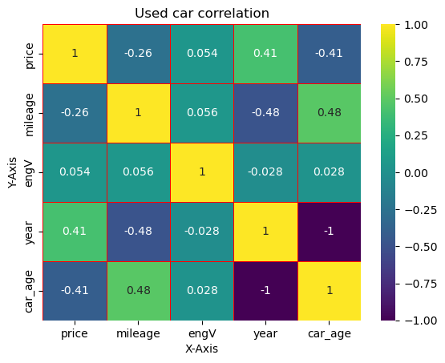

```python
sns.heatmap(data= df.corr(), annot=True, cmap='viridis', linewidth=0.5,linecolor='red')
plt.title('Used car correlation')
plt.xlabel("X-Axis")
plt.ylabel("Y-Axis")
plt.show()
```

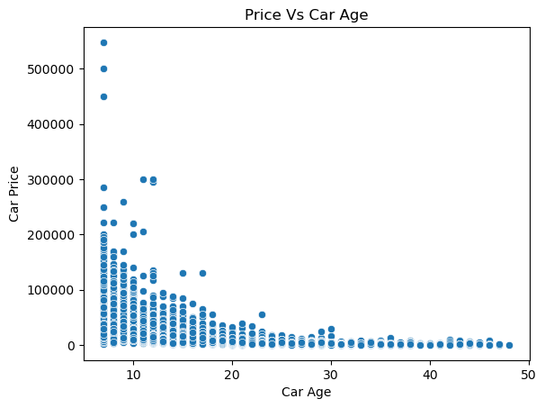

```python
sns.scatterplot(data=df,x='car_age', y='price')
plt.title('Price Vs Car Age')
plt.xlabel("Car Age")
plt.ylabel("Car Price")
plt.show()
```